```python
import numpy as np
import pandas as pd
import matplotlib.pyplot as plt
%matplotlib inline
import seaborn as sns
```

matplotlib.pyplot is a collection of command style functions that make Matplotlib work like MATLAB. Each Pyplot function makes some change to a figure. For example, a function creates a figure, a plotting area in a figure, plots some lines in a plotting area, decorates the plot with labels, etc.

# Type of Plots we can plot in matplotlib

```
Bar      :   Make a bar plot
Barh     :   Make a horizontal bar plot
Boxplot  :   Make a box and whisker plot
Hist     :   Plot a Histogram
hist2d   :   Make a 2d histogram plot
Pie      :   Plot a pie chart
Scatter  :   Make a scatter plot x vs y
Stackplot:   Draws a stacked area plot
```

# Axis Functions

```
Axes     :   Add axes to the figure
Text     :   Add text to the axes
Title    :   Set a title of the current axes
Xlabel   :   Set the axis label of the current axis.
Xlim     :   Get or set the x limits of the current axes
xscale   :   Set the scaling of the axes
Xticks   :   Get or set the x-limits of the current tick locations and labels
Ylabel   :   Set the y axis label of the current axis
Ylim     :   Get or set the y-limits of the current axis
Yscale   :   Set the scaling of y-axis
Yticks   :   Get or set the y-limits of the current tick locations and labels
```

# Figure Functions

```
Figtext  :   Add text to figure
Figure   :   Creates a new figure
Show     :   Display a figure
Savefig  :   Save the current figure
Close    :   Close the figure window
```

```python
x = [2, 4, 3, 6, 8, 7]

y = [21, 23, 19, 17, 25, 27]
```

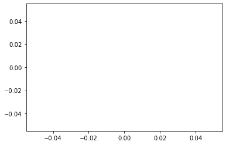

```python
# Lets create an empty plot

plt.plot()
plt.show()
```

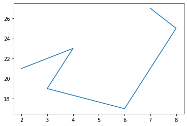

```python
plt.plot(x, y)
plt.show()                 # function to show the plot
```

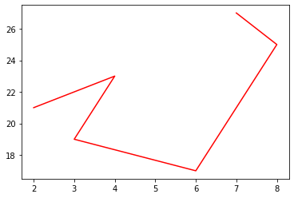

```python
# Let us add color to the graph line

plt.plot(x, y, color = 'r')          # added color to the line
# or plt.plot(x, y, 'r')
plt.show()
```

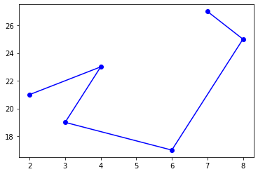

```python
# Let us add 'marker' to the graph line (instead of just line)

plt.plot(x, y, color = 'b', marker = 'o')            # added color as well as marker
plt.show()
```

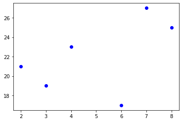

```python
plt.plot(x, y, 'bo')
plt.show()
```

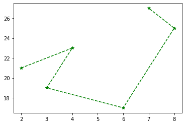

```python
# Lets add the linewidth and linestyle

plt.plot(x, y, color = 'g', marker = '*', linewidth = 1.5, linestyle = 'dashed')
plt.show()
```

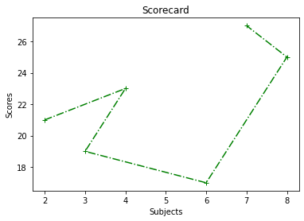

```python
# Let us add the labels to the above plot

plt.plot(x, y, color = 'g', marker = '+', linewidth = 1.5, linestyle = 'dashdot')
plt.xlabel('Subjects')
plt.ylabel('Scores')
plt.title('Scorecard')
plt.show()
```

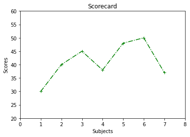

```python
# Lets add the xlim and ylim to the above plot

m = [1, 2, 3, 4, 5, 6, 7]

n = [30, 40, 45, 38, 48, 50, 37]

plt.plot(m, n, color = 'g', marker = '+', linewidth = 1.5, linestyle = 'dashdot')
plt.xlabel('Subjects')                  # adding labels to x axis
plt.ylabel('Scores')                    # adding labels to y axis
plt.title('Scorecard')                  # adding titles to entire graph

plt.xlim(left = 0, right = 8)           # setting the limit from 0 to 8 in x axis
plt.ylim(bottom = 20, top = 60)         # setting the limit from 20 to 60 in y axis
plt.show()
```

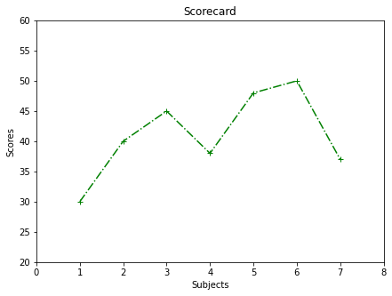

```python
# Now I want the above graph to be bigger size

m = [1, 2, 3, 4, 5, 6, 7]

n = [30, 40, 45, 38, 48, 50, 37]

plt.figure(figsize = (7, 5))             # adding the size to the below graph
plt.plot(m, n, color = 'g', marker = '+', linewidth = 1.5, linestyle = 'dashdot')
plt.xlabel('Subjects')
plt.ylabel('Scores')
plt.title('Scorecard')

plt.xlim(left = 0, right = 8)           # setting the limit from 0 to 8 in xaxis
plt.ylim(bottom = 20, top = 60)         # setting the limit from 20 to 60 in yaxis

plt.show()
```

## Now plotting two plots in same graph

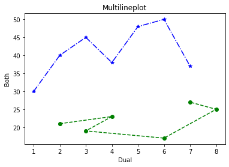

```python
x = [2, 4, 3, 6, 8, 7]

y = [21, 23, 19, 17, 25, 27]

m = [1, 2, 3, 4, 5, 6, 7]

n = [30, 40, 45, 38, 48, 50, 37]


plt.plot(x, y, color = 'g', marker = 'o', linestyle = 'dashed', linewidth = 1.5)
plt.plot(m, n, color = 'b', marker = '*', linestyle = 'dashdot', linewidth = 1.5)
plt.xlabel( 'Dual' )
plt.ylabel( "Both" )
plt.title( "Multilineplot" )
plt.show()
```

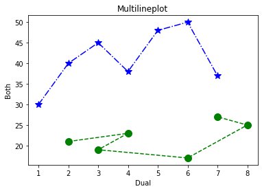

```python
x = [2, 4, 3, 6, 8, 7]

y = [21, 23, 19, 17, 25, 27]

m = [1, 2, 3, 4, 5, 6, 7]

n = [30, 40, 45, 38, 48, 50, 37]


plt.plot(x, y, color = 'g', marker = 'o', markersize = 10,linestyle = 'dashed', linewidth = 1.5)    # setting marker size
plt.plot(m, n, color = 'b', marker = '*', markersize = 10.5, linestyle = 'dashdot', linewidth = 1.5)
plt.xlabel( 'Dual' )
plt.ylabel( "Both" )
plt.title( "Multilineplot" )
plt.show()
```

## Plotting with using numpy function

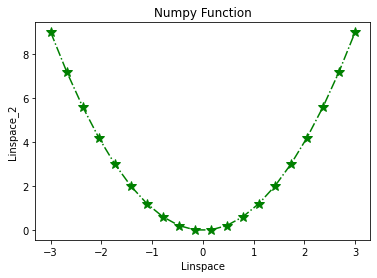

```python
# using lispace

x = np.linspace(-3, 3, 20)     # start , end, number of datapoints
y = x**2

plt.plot(x, y, color = 'g', linestyle = 'dashdot', marker = '*', markersize = 10, linewidth = 1.5)
plt.xlabel('Linspace')
plt.ylabel('Linspace_2')
plt.title('Numpy Function')
plt.show()
```

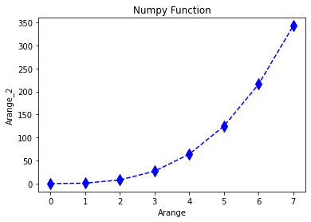

```python
# Using arange

x = np.arange(8)
y = x**3

plt.plot(x, y, color = 'b', linestyle = 'dashed', marker = 'd', markersize = 10, linewidth = 1.5)
plt.xlabel('Arange')
plt.ylabel('Arange_2')
plt.title('Numpy Function')
plt.show()
```

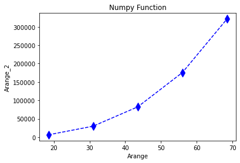

```python
# Using arange

x = np.arange(18.5, 70.5, 12.5)      # start, end, increament
y = x**3

plt.plot(x, y, color = 'b', linestyle = 'dashed', marker = 'd', markersize = 10, linewidth = 1.5)
plt.xlabel('Arange')
plt.ylabel('Arange_2')
plt.title('Numpy Function')
plt.show()
```

# Plotting with other data

```python
x = [1, 2, 3, 4, 5, 6, 7, 8, 9, 10]
y = [50, 55, 62, 66, 59, 53, 49, 44, 60, 70]
```

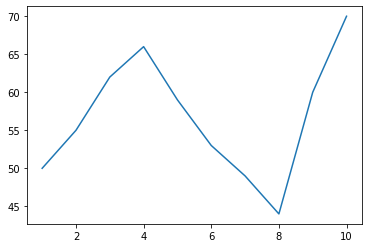

```python
# Now we have to plot the data
plt.plot(x,y)
```

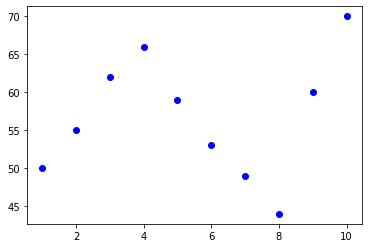

```python
plt.plot(x,y, 'bo')      # 'bo'  mean blue color 'o' marker
```

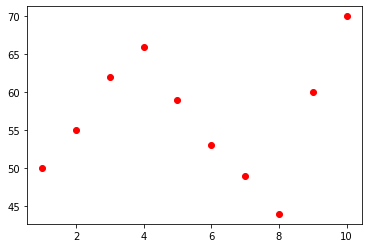

```python
plt.plot(x,y, 'ro')     # 'ro'  means red color 'o' marker
```

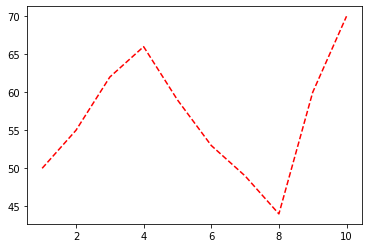

```python
plt.plot(x,y, 'r--')    # 'r--' mean red color line with '--'
```

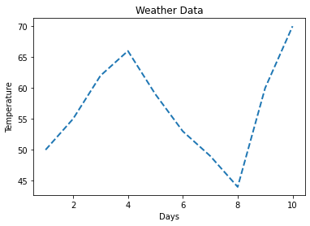

```python
# Now let me define the xlabel and ylabel with the title

plt.xlabel('Days')                                              # setting the x label
plt.ylabel('Temperature')                                       # setting the y label
plt.title("Weather Data")                                       # setting the title

plt.plot(x,y, ls = '--', lw = 2.0)     # lw mean linewidth, ls mean 'linestyle'
plt.show()
```

# Basic plotting

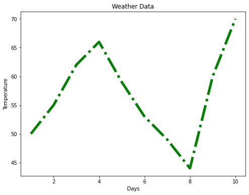

```python
plt.figure(figsize = (8,6))      # setting the figure size
plt.xlabel('Days')
plt.ylabel('Temperature')
plt.title("Weather Data")
plt.plot(x,y, color = 'Green', linewidth = 5.0, linestyle = 'dashdot')
# here linewidht can also be written as lw (int values can be specified)
# here linestyle can also be written as ls
```

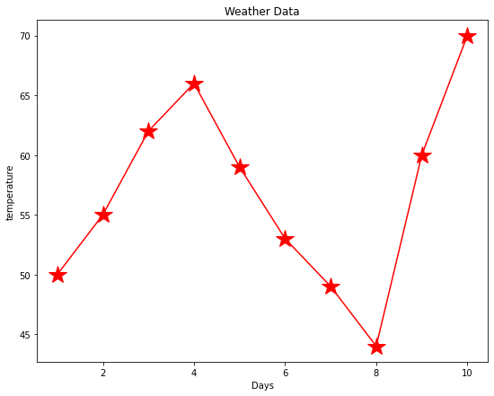

```python
# Now I want to change the marker tip style
plt.figure(figsize = (9,7))
plt.xlabel("Days")
plt.ylabel("temperature")
plt.title("Weather Data")
plt.plot(x,y, marker = '*', color = 'red', markersize = 20) # setting marker size
```

## Alpha mean transparancy

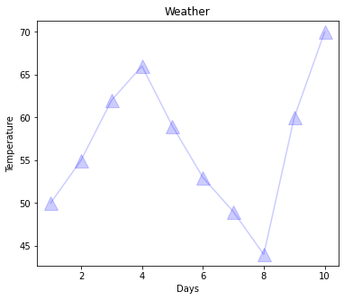

```python
# another plot

plt.figure(figsize = (6,5))
plt.xlabel('Days')
plt.ylabel('Temperature')
plt.title('Weather')
plt.plot(x,y, marker = '^', color = 'b', markersize = 15, alpha = 0.2) # alpha is transparancy
```

## I can also specify all three (linecolor, markerstyle and linestyle in same 'gD--')

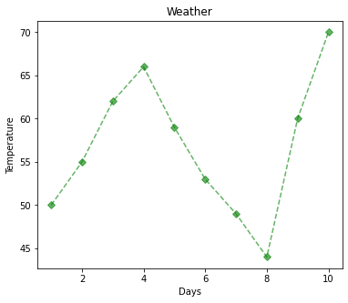

```python
# another plot
plt.figure(figsize = (6,5))
plt.xlabel('Days')
plt.ylabel('Temperature')
plt.title('Weather')
plt.plot(x,y, 'gD--', alpha = 0.6)     # I can either specify linewidth = 10, markersize = 10
```

# plt,show() # only makes the [<matplotlib.lines.Line2D at 0x27ca135eac8>] disapper

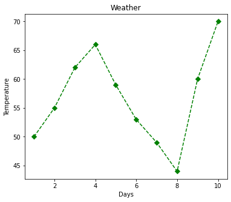

```python
# another plot
plt.figure(figsize = (6,5))
plt.xlabel('Days')
plt.ylabel('Temperature')
plt.title('Weather')
plt.plot(x,y, 'gD--', alpha = 1)     # I can either specify linewidth = 10, markersize = 10
plt.show()
```

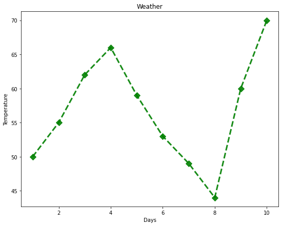

```python
# main plot
plt.figure(figsize = (9,7))
plt.xlabel('Days')
plt.ylabel('Temperature')
plt.title('Weather')
plt.plot(x, y, color = 'Green', linewidth = 3, linestyle = '--', marker = 'D', markersize = 8, alpha = 0.9)
```

# Note : alpha basically controls the transparancy (alpha = can either be b/w 0 - 1)

# Note : just in case if we have only one input value like x or y1

```python
# Creating simple line chart
y = [2, 6, 8, 11, 13, 15, 17, 18]
```

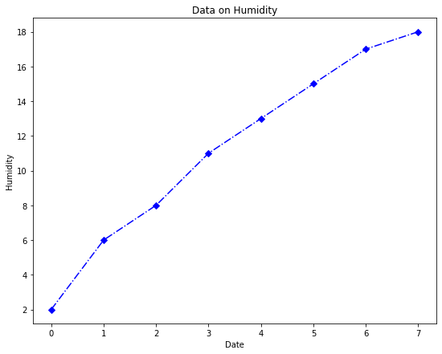

```python
plt.figure(figsize = (9, 7))
plt.xlabel('Date')
plt.ylabel('Humidity')
plt.title('Data on Humidity')
plt.plot(y, 'bD-.')
plt.show()
```

# Multiple line chart¶ We can either specify x and y in [] or ()

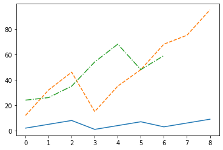

```python
x = [2, 5, 8 , 1 , 4 , 7, 3, 6, 9]
y = [12, 32, 46, 15, 35, 48, 68, 75, 95]
y1 = [24, 26, 35, 54, 68, 48, 59]
plt.plot(x)
plt.plot(y, '--')
plt.plot(y1, '-.')
```

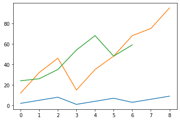

```python
x = (2, 5, 8 , 1 , 4 , 7, 3, 6, 9)
y = (12, 32, 46, 15, 35, 48, 68, 75, 95)
y1 = (24, 26, 35, 54, 68, 48, 59)
plt.plot(x)
plt.plot(y)
plt.plot(y1)
```

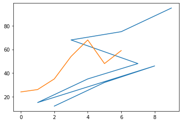

```python
x = [2, 5, 8 , 1 , 4 , 7, 3, 6, 9]
y = [12, 32, 46, 15, 35, 48, 68, 75, 95]
y1 = [24, 26, 35, 54, 68, 48, 59, ]
plt.plot(x,y,y1)
```

# Adding Lengend

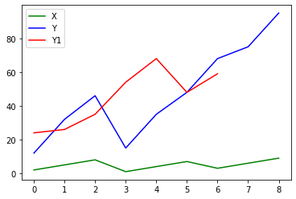

```python
x = [2, 5, 8 , 1 , 4 , 7, 3, 6, 9]
y = [12, 32, 46, 15, 35, 48, 68, 75, 95]
y1 = [24, 26, 35, 54, 68, 48, 59, ]
plt.figure(figsize = (6,4))
plt.plot(x, label = "X",color = 'g')
plt.plot(y, label = "Y", color = 'b')
plt.plot(y1, label = 'Y1', color = 'r')
plt.legend(loc = 2)
plt.show()
```

# to change the location of legend to either top left plt.legend(loc = 2), (loc =1) for top right, bottom left (loc = 3)

# Now if you want to plot as graph without axis : plt.axis('off')

```python
# Note that plt.axis('off') needs to be added before legend.
```

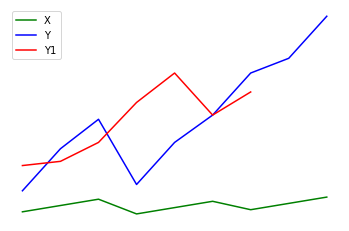

```python
x = [2, 5, 8 , 1 , 4 , 7, 3, 6, 9]
y = [12, 32, 46, 15, 35, 48, 68, 75, 95]
y1 = [24, 26, 35, 54, 68, 48, 59, ]
plt.figure(figsize = (6,4))
plt.plot(x, label = "X",color = 'g')
plt.plot(y, label = "Y", color = 'b')
plt.plot(y1, label = 'Y1', color = 'r')
plt.axis('off')
plt.legend(loc = 2)
plt.show()
```